```python
import copy
import numpy as np
import pandas as pd
import matplotlib.pyplot as plt
import matplotlib.style as style
import matplotlib.gridspec as gridspec
import seaborn as sns
from mpl_toolkits import mplot3d
from scipy import stats
%matplotlib inline
```

```python
df = pd.read_csv('./data_mod_1.csv')
```

# Exploring State Zip WA 98103

The 148 samples in WA 98103 is a comfortable amount of work with, to verify our machine learning algorithm results with hand calculations. After verifying the algorithm, the algorithm will be extended to the rest of the 4550 samples in the original dataframe, that comprises the entire Seattle region.

### State ZIP WA 98103 on the map

[figure not shown]

```python
df_4 = df.loc[ (df['statezip'] == 'WA 98103'), ['bedrooms', 'bathrooms', 'sqft_living', 'floors', 'condition', 'price'] ]
```

We chose the features in dataframe_4 because, intuitively, these would seem as the most significant. In other words, if I was to purchase a house, the size (sqft), the condition and the location would be the most important features.

```python
X_ = df_4.sqft_living  # sqft is the most telling of price
```

```python
X = X_.to_numpy()  # we want a numpy array
```

##### Data Preprocessing for Linear Regression

```python
ones = np.ones(len(X))  # adding a ones column in front
X_with_ones_col = np.column_stack((ones, X))
```

##### our target: y

```python
y_ = df_4.price
y = y_.to_numpy()
```

# §1.0 Applying Machine Learning Models

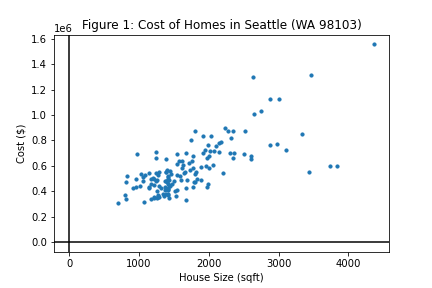

```python
fig4, ax4 = plt.subplots()

ax4.scatter(X, y, s=10)  # plot looks fine
ax4.axhline(0, color='black')
ax4.axvline(0, color='black')
ax4.set_title("Figure 1: Cost of Homes in Seattle (WA 98103)")
ax4.set_xlabel("House Size (sqft)")
ax4.set_ylabel("Cost ($)")
```

In Figure 1, there is a trend of cost increasing with sqft. This is a typical linear regression problem. In more detail, this is a univariate linear regression model and we are trying to fit a hypothesis.

1. In §1.1, we use sklearns LinearRegression library to determine the weights.
2. In §1.2, we use an analytic approach. These weights will be compared to the weights determined by the sklearn library.
3. In §1.3, we determine a cost function and apply a gradient descent learning algorithm on the cost function.

The weights from the second approach will be compared to the weights determined by an analytic solution. We compare it this manner because there are less moving parts in an analytic approach. You just need to ensure the design matrix and target are sized appropriately, and apply a series of basic linear algebra techniques such as inversion, multiplication on the design matrix and the target.

## §1.1 Linear Regression with the sklearn Library

```python
from sklearn import datasets
from sklearn import linear_model
from sklearn.model_selection import train_test_split
```

```python
model = l_reg.fit(X_with_ones_col, y)
test_val = np.array([[1, 2000]])
```

```python
l_reg.coef_
```

```
array([  0.        , 229.49521863])
```

```python
l_reg.intercept_
```

```
184435.24482113082
```

From the sklearn, the weights for w<sub>0</sub> and w<sub>1</sub> are 184435.2 and 229.5 respectively.

```python
model.predict(test_val)
```

```
array([643425.6820888])
```

The model generated by sklearn predicts a housing value of $643425.

## §1.2 An Analytic Approach

If we wanted to do this at a lower level, there are two ways to solve this. After determining the weights from with the linear regression machine learning model provided by the sklearn package, we will find the weights 'by hand' as well. There are many ways to do this. In this project, we will be employing the following two approaches to find the weights, similar to Lab 2.

Its very convenient to be able to calculate the weights with the following approach. In fact this is the best way to solve this problem for this situation (excluding sklearn)

As mentioned above, since there's only one feature to consider (sqft), we can solve for the weights with an analytic approach. Essentially, this means using basic linear algebra techniques, to solve for our weight, weights being our slope and intercept in this single-featured example.

The advantages of an analytic approach:

- no need for gradient descent
- no need to perform thousands of iterations
- no need for learning rate guesswork
- no need for feature scaling

In fact, the entire solution can be solved with an analytic approach. If the code is vectorized, an analytic approach would work up to even 10,000 features.

```python
def normal_equation(X, y):
    return np.linalg.inv(X.T @ X) @ X.T @ y
```

```python
normal_equation(X_with_ones_col, y)
```

```
array([184435.24482113,    229.49521863])
```

From our analytic approach, the weights for w<sub>0</sub> and w<sub>1</sub> are 184435.2 and 229.5 respectively. These values are exactly the same as the values from sklearn.

### Test with 2000 sqft

These are our weights. If we run a test. if we have 2000 sqft. then ...

```python
184435.2448 + 229.4952 * 2000
```

```
643425.6448
```

## §1.3 Developing a Cost Function

Approach 2 is more involved, for example, one has to adjust the number of iterations, guess the learning rate and more (more discussed below). Since more things can go wrong with gradient descent than the analytic solution, the results from gradient descent+cost function is compared to the analytic solution.

We explore how to solve for the weights with gradient descent on a cost function because in some situation, gradient descent works where the normal equation cannot be applied, like for example in logistic regression, knn.

### §1.3.1 Scaling Down

For plotting purposes, it would be ideal to have weights close in value so that the cost function looks decent. I'm going to scale the X by 1000 and the scale the y by 100,000.

The cost function can be contrived with the original values, and the weights correctly come out as w<sub>0</sub>=184435.2 and w<sub>1</sub>= 229.5, but the cost function does not look good.

Note that, I could scale down with standard feature scaling techniques as well ( subtracting the mean and divide by the standard deviation from each value) but I've opted not to because I want to get a scaled down value by tens (ie 184435 -> 1.84) of what we got from sklearn and from the analytic solution, so that all three approaches are comparable.

```python
X_scaled = X/1000
```

```python
X_scaled_with_ones_col = np.column_stack((np.ones(len(X_scaled)), X_scaled))
```

```python
y_scaled = y/100000
```

If we use the normal equation, we get the following weights

```python
normal_equation(X_scaled_with_ones_col, y_scaled)
```

```
array([1.84435245, 2.29495219])
```

These weights (w0=1.84 and w1=2.29) are much closer in value now, it will be much easier to visualize in a plot.

Note that, the weight values changed from

w<sub>0</sub>=184435.2 and w<sub>1</sub>= 229.5 to **w<sub>0</sub>=1.84 and w<sub>1</sub>= 2.29**

So really important note for below, we know that the cost function and gradient descent were done correctly if it yields w<sub>0</sub>=1.84 and w<sub>1</sub>= 2.29. w1=2.29.

## §1.4 Plotting the Cost Function

The cost function, tests all pairs of weights w<sub>0</sub>and w<sub>1</sub> and plot them in a specified range.

#### §1.4.1 Contour Plot of the Cost Function

[figure not shown]

```python
def plot(g):
    g2 = g*g
    steps = np.linspace(-4, 6, g)
    w0, w1 = np.meshgrid(steps, steps)
    w0_ = w0.ravel()
    w1_ = w1.ravel()
    w = np.column_stack([w0_, w1_])

    def calculateCostArray(X, y, i):
        return computeCost(X, y, w[i])

    def computeCost(X, y, w):
        t = X @ w - y
        t_squared = t * t   # vectorized. element wise squaring
        cost = 1/(2*len(X)) * sum(t_squared)
        return cost

    costs = np.zeros(g2)
    for i in range(g2):
        costs[i] = calculateCostArray(X_scaled_with_ones_col, y_scaled, i)

    costs = costs.reshape(g, g, -1)
    costs = costs.squeeze()

    fig3, ax3 = plt.subplots()

    ax3.imshow(costs, origin='lower', extent=(w0.min(), w0.max(), w1.min(), w1.max()))
    ax3.set_title("Cost Function of all the Samples in Figure 1")
    ax3.set_xlabel('$w_0$')
    ax3.set_ylabel('$w_1$')
#     ax3.colorbar()
#     ax3.xlabel('$w_0$')
#     ax3.ylabel('$w_1$')
#     ax3.title('Plot of $cost(\\mathbf{w})$')
#     ax3.gca().set_aspect('equal')  # Force the x and y axes to scale


    ax3.contour(w0, w1, costs, colors='white', linestyles=':')


plot(100)
```

this looks good. Upon visual inspection the cost function, I can see that w<sub>0</sub>=1.84 and w<sub>1</sub>= 2.29 does seem to lie in the darkest part of the cost function. The cost function will be a bowl like shape. Since there's only one feature, I'm aware that there will be only one global minimum. I know this because when I did my hand calculations with just three samples, I've noticed that, the cost function ends up as a 2nd degree polynomial, and that always has a shape of a bowl. Adding more samples to our cost function will still only produce a second degree polynomial, hence one global minimum.

The darkest region within this cost function represents the lowest point of our cost function. We want to let the algorithm know, that has to pay a cost, for the the pair of weights (w0, w1) it picks. Every pair of weights has an associated cost. An algorithm will pick the lowest point on the cost function as this corresponds to the lowest cost.

#### §1.4.2 Interactive 3-D Plot of the Cost Function

we can also visualize the cost function in a 3D space, instead of a contour plot. I found this one more useful for understanding.

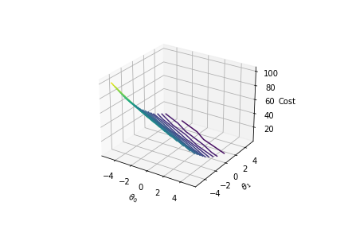

```python
%matplotlib notebook

from mpl_toolkits.mplot3d import axes3d

bounds = 5

x1 = np.linspace(-bounds, bounds, 5)
x2 = np.linspace(-bounds, bounds, 5)

X1, X2 = np.meshgrid(x1, x2)

# Z = f(X1, X2)

fig1, ax1 = plt.subplots()
# fig = plt.figure()
ax1 = plt.axes(projection='3d')

ax1.contour3D(X1, X2, costs, 30)
# ax.plot_wireframe(X1, X2, Z, rstride=5, cstride=5)


ax1.set_xlabel(r'$\theta_0$')
ax1.set_ylabel(r'$\theta_1$')
ax1.set_zlabel('Cost')
```

Where we are in the project => We have a cost function representation.

Now we need to apply gradient descent to our cost function. A gradient descent algorithm with a good learning rate, and sufficient iterations, we need to get w<sub>0</sub>=1.84 and w<sub>1</sub>= 2.29

## §1.5 Gradient Descent

As can be seen in our function definition, we guess the weights as w<sub>0</sub>=0 and w<sub>1</sub>= 0.

With gradient descent, our objective is to minimize the weights w<sub>0</sub> and w<sub>1</sub> such that the cost is the lowest. Essentially, the algorithm is paying a 'cost' for the parameters it picks, so it 'learns' by picking the weights with the lowest cost.

Basically you are instructing the algorthm, 'Find me the values of w<sub>0</sub> and w<sub>1</sub> that gives me the minimum of a cost function.'

Recap that from the normal equation, what we're supposed to be getting

w<sub>0</sub>=1.84 and w<sub>1</sub>=2.29

```python
normal_equation(X_scaled_with_ones_col, y_scaled)
```

```
array([1.84435245, 2.29495219])
```

To get started with gradient descent, we define it from Lab 2

```python
def gradient_descent(X, y, learn_rate=0.00004, num_steps= 10000):
    w = np.array([0, 0]) # so instead of guessing x, we're guessing w
    for i in range(num_steps):
        grad = (X.T @ X) @ w - X.T @ y  # so.. this is a very useful equation
        w = w - learn_rate*grad
    return w
```

```python
w_from_gradient_descent = gradient_descent(X_scaled_with_ones_col, y_scaled)
w_from_gradient_descent
```

```
array([1.84270283, 2.29581986])
```

With gradient descent, we come up with values w<sub>0</sub>=1.84 and w<sub>1</sub>= 2.29, the same answer as our above approaches and the answer we were expecting.

## §1.6 Gradient Descent on our Cost Function

[figure not shown]

```python
plot(100)
plt.plot(*w_from_gradient_descent, 'xr')
```

## §2.0 Conclusion

Up to now, we have only considered a single feature, the size of the house (sqft). We are limited to only a single feature if we want to be able to plot. If we had more than one feature, we cannot visualize the cost function and gradient descent actually descending. When more features are added, ℝ moves into higher dimensions and we lose the visual aspect of it all because we cannot plot the cost function anymore. This is important because a visualizing this greatly helps understand the mechanics of gradient descent for other machine learning techniques.

The plan is to see if our weights make sense. the gradient descent to work and include all the features, such as bathrooms, condition of the house etc.